# Problem Set 5

Due: October 26, 2026

Just two questions this week! Question 1 on this problem set is about using lists for tabulation and working with `GCompound`s. Question 2 is about working with multidimensional arrays. Files are provided in the starting template linked before for both questions. Make sure you fill out the top metadata on each problem please!

[Accept Assignment](https://classroom50.org/Agbo-CS151/cs151-fa-2026/assignments/problem-set-5/accept)

# Problem 1

A common form of tabulation is that of creating a “histogram”, wherein the different elements of the histogram array represent the counts of how many times a particular value (or range of values) showed up in a certain collection. For example, the first 16 digits of $\pi$ look like:

```python
PI_DIGITS = [ 3, 1, 4, 1, 5, 9, 2, 6, 5, 3, 5, 5, 8, 9, 7, 9 ]
```

If we are dealing with single digits, then there are 10 possible values that we could want to count: the digits 0 through 9. It turns out that these digits map nicely to the index values of an array! So we could store how many times a 0 appears in `PI_DIGITS` (0 times) in the index 0 element of our histogram, and the number of times the digit 1 appears (2 times) in the index 1 element, and so on. The entire histogram array, once populated, might look like:

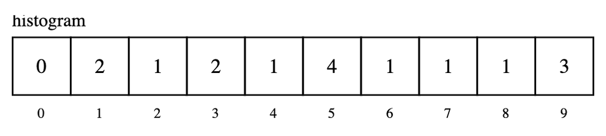

showing that there are no 0s, two 1s, one 2, two 3s, etc. in the first sixteen digits of $\pi$.

## Part A

Write a function called `create_histogram_array(imax, data)` which takes two values as arguments:

- A maximum index `imax`, which represents the total number of possible things you would like to count. This would have been 10 in our above example.
- A list of integers `data`, which represents the items for which you would like to tabulate a histogram.

This function should return a new list which has the histogram counts as each element. For example, your function should be able to mimic:

```
>>> create_histogram_array(5, [1, 0, 3, 2, 4, 2, 2, 1, 3, 0])
[2, 2, 3, 2, 1]
```

where `imax` was chosen to be 5 since there were 5 different values appearing in the `data` list (0 through 4). Note though that if your value of `imax` is smaller than the variety of digits in `data`, the later digits will not be counted. Only the first `imax` digits will be counted. If `imax` is larger than the number of different digits in `data`, 0’s will be counted for those extra digits. So, for instance:

```
>>> create_histogram_array(3, [1, 0, 3, 2, 4, 2, 2, 1, 3, 0])
[2, 2, 3]
>>> create_histogram_array(8, [1, 0, 3, 2, 4, 2, 2, 1, 3, 0])
[2, 2, 3, 2, 1, 0, 0, 0]
```

## Part B

Now that you can use your function from Part A to compute a histogram array, how about displaying it nicely to the screen? For this part, write a new function called `print_histogram(array)` that take a histogram counts list (of the exact sort returned by `create_histogram_array`!) as an argument. This function should print to the console a rotated histogram using asterisks to indicate the count of values in each index. For example, if you call `print_histogram` with the histogram formed by the first 16 digits of $\pi$, you should see the following:

```
>>> print_histogram(create_histogram_array(PI_DIGITS))
0:
1: **
2: *
3: **
4: *
5: ****
6: *
7: *
8: *
9: ***
```

Your function should mimic this printing *exactly*. This should not be particularly complicated, as you have all the necessary tools with string formatting and the repetition operator for strings.

## Part C

While printing to the console is one way to visualize a histogram, it is not the classical graphical way. So for this part, you should write a function called `create_histogram_graph(array, width, height)` which will use PGL to create a histogram `GCompound`. The `array` parameter represents the same input array as from Part B (or the returned output from Part A), and the `width` and `height` parameters represent the desired size of the `GCompound`. You will need to use these values to figure out how wide and tall each of your histogram rectangles should be. The function should return a `GCompound` object that contains filled `GRect` objects arranged to produce a traditional bar graph histogram, where the height of a particular box reflects the proportional number of items in that index in the histogram array. The scaling of the bars should be chosen so that the largest bar in the graph completely fills the desired height, and all the bars arranged next to one another should completely fill the desired width. The reference point of the `GCompound` should be the upper left corner.

To illustrate how this part should work, it may help to consider the following simple test program, which is included in the code template:

```python
def test_create_histogram_graph():
    WIDTH, HEIGHT = 800, 600
    gw = GWindow(WIDTH, HEIGHT)
    PI_DIGITS = [3, 1, 4, 1, 5, 9, 2, 6, 5, 3, 5, 5, 8, 9, 7, 9]
    array = create_histogram_array(10, PI_DIGITS)
    graph = test_create_histogram_graph(array, WIDTH, HEIGHT)
    gw.add(graph)
```

which should display the following graph so that it fills the graphics window:

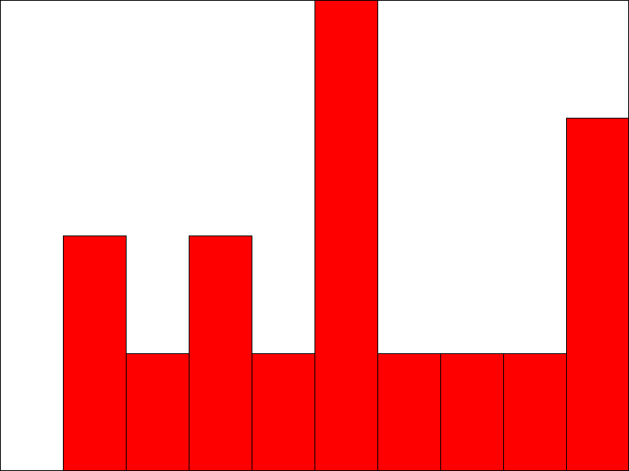

Note that because `create_histogram_graph` just returns to you a `GCompound`, if you made 4 of them with half the width and height of the window, you could also display multiple across the screen by adding them at the correct coordinates:

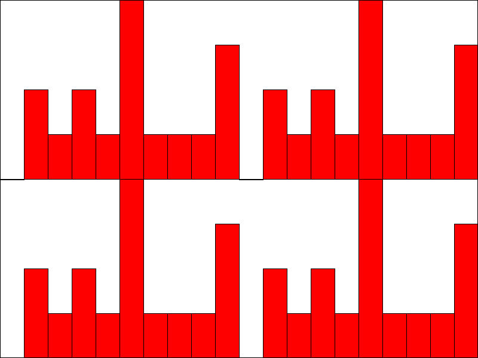

# Problem 2

A *magic square* is a two-dimensional array of integers in which the rows, columns, and diagonals all add up to the same value. One of the most famous magic squares appears in the 1514 engraving *Melencolia I* by Albrecht Dürer shown below, in which a 4x4 magic square appears in the upper right, just under the bell. In Dürer’s square, all four rows, all four columns, and both diagonals add up to 34.

[figure not shown]

The *Melencolia I* by Albrecht Dürer, in which a magic square is visible in the upper right, just under the bell.

A more familiar example is the following 3x3 magic square, in which each of the rows, columns, and diagonals add up to 15, as shown:

[figure not shown]

A 3x3 magic square summing to 15

Write a predicate function called `is_magic_square` that takes a two-dimensional array of integers and then tests whether that array of integers forms a magic square. The square could be of any size and the rows, columns, and diagonals could sum to any value. Your function should return `True` if the array forms a magic square, or `False` if it does not. Thus your function should also return `False` if the provided two-dimensional array is not square (for instance, if it is a 4x3 array).